# Interactive graphics

6 June 2016

## Why - presenting research results

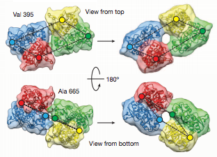

Nature, October 2014

## Interactive graphics - teaching

Least squares estimation

Linear regression model

\[ y_i = \alpha + \beta x_i + \epsilon \]

Estimates for the intercept and slope can be found by minimizing the squared residuals.

\[ \arg_{\alpha, \beta} \min \sum_i \left(y_i - (\alpha + \beta x_i) \right)^2 \]

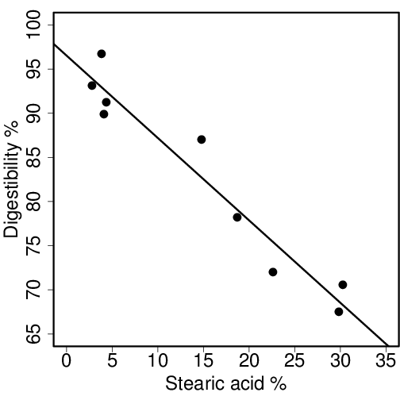

## Why - teaching

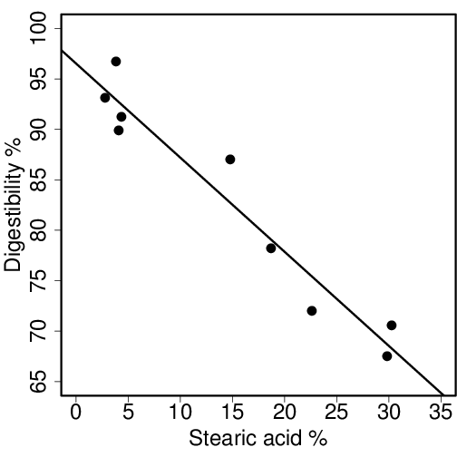

## Why - teaching

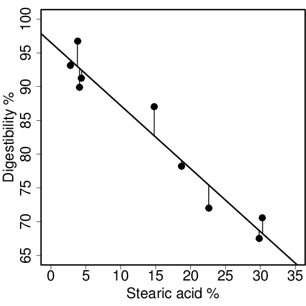

## Why - teaching

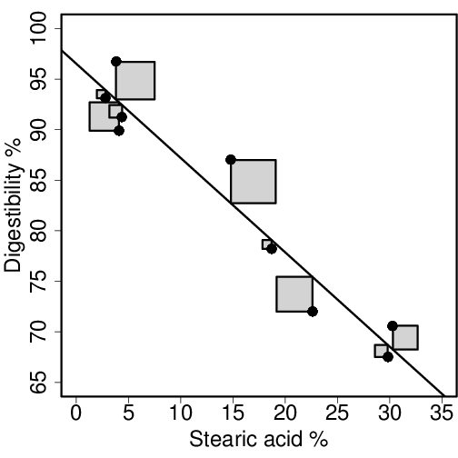

## Why - teaching

Slidify

```r
library(shiny)
runGitHub('ekstroem/ShinyLeastSquares')
```

## Background

### Toby

### Claus

- Dept. Biostatistics, UCPH

## Outline for the tutorial

Tutorial goals:

## Necessary stuff

Necesary packages etc

Rstudio

See also: Toby's link

devtools::install_github("ramnathv/rCharts")

## Concepts

Tobys slides terms / discussion

- multi-layer, multi-panel, multi-plot
- animation, direct manipulation (clicking, hovering), indirect manipulation (buttons, menus)
- zoom, highlight, show/hide (data, labels, tooltips)

## The role of the viewer

Thinking about graphics

## Quiz

Or something else. Quick example quiz

[figure not shown]

Use kahoot.com?

## Interactive graphics architechture

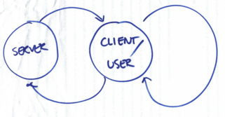

Architechture

Dedicated server vs. local server

## d3.js

JavaScript libraries, D3.js doesn’t ship with any pre-built charts out of the box. However, you can look at the list of graphs built with D3.js to get an overview.

- ChartJS
- Chartist.js
- n3
- plotly

### R and Javascript architecture

R -> package -> javascript library -> html/javascript

View in browser. More problematic to share

## Highlevel interactive graphics

Numerous possibilities in R

- rCharts
- highcharter
- dygraph
- plotly
- **htmlwidgets**

R markdown + Markdown + embedded R code chunks like knitr + .Rmd -> .md -> .html (docx, pdf) + RStudio: "Knit" command (Ctrl+Shift+K)

## rCharts interfaces

| library | function |  |
| --- | --- | --- |
| [polychart](http://www.polychart.com/js/) | rPlot | ggplot2-like |
| [Morris](http://morrisjs.github.io/morris.js/) | mPlot | Pretty time series |
| [nvd3](http://nvd3.org) | nPlot | Lines/areas/bars |
| [xCharts](http://tenxer.github.io/xcharts/) | xPlot | Various graphs |
| [Highcharts](http://www.highcharts.com/) | hPlot | Interactive charts |
| [Leaflet](http://leafletjs.com/) | new() | Interactive Maps |
| [Rickshaw](http://code.shutterstock.com/rickshaw/) | new() | Real-time ts graphs |
| [Dimple](http://www.dimplejs.org) | dPlot | Business analytics |
| [metricsgraphics](http://metricsgraphicsjs.org/) | mjs_plot | Time-series |
| [dygraphs](http://dygraphs.com/) | dygraph | Time-series |

## polychart

R-like

## Highcharts - highcharter

[figure not shown]

HighCharter

## highcharter

Start with empty chart and add components.

Simple bar plot

```r
library(highcharter)
hc <- highchart() %>%
  hc_chart(type = "column") %>%
  hc_title(text = "A highcharter chart") %>%
  hc_xAxis(categories = 2012:2016) %>%
  hc_add_series(data = c(3900,  4200,  5700,  8500, 11900),
                name = "Downloads")
hc
```

[interactive chart not shown]

## Highcharter - adding data

hc_add_series / hc_add_series_list hc_add_series_df add_serie_scatter

## Highcharter - scatter points and lines

[interactive chart not shown]

## Highcharter function overview

Function, types

## Highcharter - adding information

[interactive chart not shown]

## Highcharter function overview

References

## dygraph

```r
library(dygraphs)
dygraph(nhtemp, main = "New Haven Temperatures") %>%
  dyRangeSelector(dateWindow = c("1920-01-01", "1960-01-01"))
```

[interactive chart not shown]

## dygraphs 2

[interactive chart not shown]

## metricsgraphics

[interactive chart not shown]

## Metricgraphics

```r
library(RColorBrewer)

tmp <- data.frame(year=seq(1790, 1970, 10), uspop=as.numeric(uspop))

tmp %>%
  mjs_plot(x=year, y=uspop) %>%
  mjs_point() %>%
  mjs_add_marker(1850, "Something Wonderful") %>%
  mjs_add_baseline(150, "Something Awful")
```

## Metricgraphics

[interactive chart not shown]

## Metricgraphics function overview

## leaflet

```r
library(leaflet)
library(MESS)


data(earthquakes)
m <- leaflet() %>%
  addTiles() %>%  # Add default OpenStreetMap map tiles
  addMarkers(lng=earthquakes$longitude[earthquakes$mag>6],          lat=earthquakes$latitude[earthquakes$mag>6], popup="Mag 6+")
m
```

## leaflet

[interactive chart not shown]

## leaflet function overview

## rMaps - choropleths

[output not shown]

## Publishing interactive graphics

html output. Need javascript machinery to run.

```r
saveWidget()
```

self_contained: false

html

standalone

javascript

images

## Including in R markdown

savewidget iframe

## Exercise

## Shiny and plotly

## plotly + ggplotly

Differences to other libraries … public

## ggplotly - ggplot2

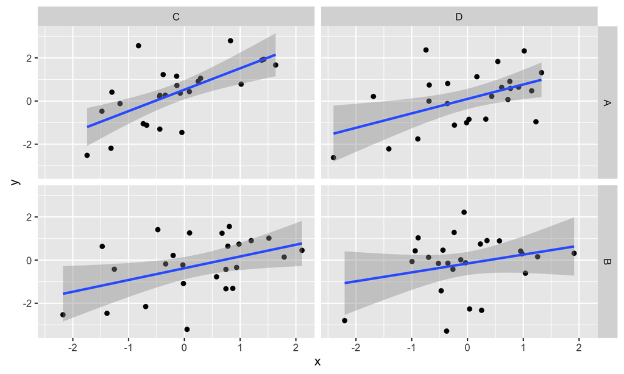

[interactive chart not shown]

## Exercise

## Shiny

Use standard R. Rather simple and beautiful. Simple input - no fancy transitions. Requires server

## Example

```r
library(shiny)
runGitHub('ekstroem/ShinySampleMean')
```

## Quick introduction to Shiny

## Shiny User Interface

## Shiny server interface

## Example

ui.R

server.R

## Building the user interface

## User interface functions

## Example -> product

## Building the server side

## Server side functions

## Example -> product

## Finished product

## ui.R

## server.R

## Running apps

Running apps from Github

## Exercise

## Remember

High-level interactive plotting packages, 30 minutes • Simple approaches like rotating plots (rgl package) and simple user interaction (wallyplot from MESS package). • Interactive bar plots (rCharts, several different JavaScript interfaces, interfacing with JavaScript libraries to change axes and legends) • Interactive scatter plots showing happiness and tax rate (rCharts, and clickme packages, several different JavaScript interfaces, add dropdown effects and improve tooltips) • interactive maps and choropleths (the rMaps packages) • Discussion of frustrations that new users unfamiliar with JavaScript may encounter when interfacing with JavaScript libraries

Interactive graphics with shiny and plotly, 30 minutes • Teaching least squares estimation (shiny) • Teaching power calculations (shiny) • Reproducing some of the previous graphics on happiness and tax rate in plotly (ggplot2, and ggplotly, adding tooltips/hover effects, and dropdown) • Graphics on prediction accuracy for Danish population predictions (plotly, adding sliders)